# FinalProject

Nadia Pressley

2026-10-01

```r
knitr::opts_chunk$set(echo = TRUE, message = FALSE, warning = FALSE)
```

```r
library(tidyverse)
library(janitor)
```

```r
data <- read.csv2("data/data.csv")
```

## Introduction

This data set is exploring the different demographics of students in higher education. The data set was designed with the purpose of helping students that are at risk in order to offer further educational support. The data came from “Early Prediction of student’s Performance in Higher” by Mónica V. Martins, Daniel Tolledo, Jorge Machado, Luís M. T. Baptista, and Valentim Realinho. The data was found on UC Irvene Machine Learning Repository, “https://archive.ics.uci.edu/dataset/697/predict+students+dropout+and+academic+success”. The data was collected from 2008 to 2019, the researcher were about to gather the data by combining several data sets together from different sources. Each row of the represents a student and their duration at a higher education school for one year, there are 4424 rows in the data set. I will be trying to create a predictive model to decipher weather there is a student will drop out, stay enrolled, or graduate based on their demographics. I plan on identifying which factors are associated with a students success or failure at these institutions. The variables I will be taking into account to help answer my research question of identifying which factors are associates with academic success are; martial status, course, previous qualifications, parent’s education level, gender, admission grade, age of enrollment, parents occupation, educational special needs, scholarship holder and tuition fees, target. As a college student, I am interested in whether identifiable patterns in students backgrounds relate to academic success. For this proposal, I treat students who remain enrolled or graduate as academically successful, and students who drop out as at risk.

## Variables selection

The data set contains 36 predictor variables, so I narrowed my focus to those that describe a student’s background and circumstances at or near enrollment. This fits the dataset’s purpose of identifying at-risk students early, before academic performance data are available. I selected demographic variables, and two financial variables scholarship holder and tuition fees up to date. I excluded first and second semester course performance variables, since they would obscure the role of background factors. Nationality was also excluded since the data set seemed to mix in nationality as well languages making it difficult to distinguish nationality of each student. I also excluded economic variables such as unemployment, inflation, GDP since they describe the economy rather than individual students.

## Cleaning and Tidying Data

The data set required some basic cleaning with such as re-coding gender from numerical values to categorical value. Martial status also needed to be re- coded to from numerical values both mother and father’s occupation and education level needed to be changed from numerical values to categorical values. The data set also needed to be filtered for select columns, and have column names cleaned.

```r
#Recoding and cleaning data
students <- data |>
  clean_names() |>
  select(marital_status,
         course,
         previous_qualification,
         mother_s_qualification, father_s_qualification,
         mother_s_occupation, father_s_occupation,
         gender,
         admission_grade,
         age_at_enrollment,
         educational_special_needs,
         scholarship_holder,
         tuition_fees_up_to_date,
         target
         ) |>
  mutate(
    gender = case_when(
      gender == "1" ~ "Male",
      gender == "0" ~ "Female",
      TRUE             ~ as.character(gender)
    ),

    marital_status = case_when (
      marital_status == 1 ~ "single",
      marital_status == 2 ~ "married",
      marital_status == 3 ~ "widower",
      marital_status == 4 ~ "divorced",
      marital_status == 5 ~ "facto union",
      marital_status == 6 ~ "legally seperated",
      TRUE                  ~ as.character(marital_status)
    ),


    course = case_when(
      course == 33   ~ "Biofuel Production Tech",
      course == 171  ~ "Animation & Multimedia Design",
      course == 8014 ~ "Social Service (evening)",
      course == 9003 ~ "Agronomy",
      course == 9070 ~ "Communication Design",
      course == 9085 ~ "Veterinary Nursing",
      course == 9119 ~ "Informatics Engineering",
      course == 9130 ~ "Equinculture",
      course == 9147 ~ "Management",
      course == 9238 ~ "Social Service",
      course == 9254 ~ "Tourism",
      course == 9500 ~ "Nursing",
      course == 9556 ~ "Oral Hygiene",
      course == 9670 ~ "Advertising & Marketing Mgmt",
      course == 9773 ~ "Journalism & Communication",
      course == 9853 ~ "Basic Education",
      course == 9991 ~ "Management (evening)",
      TRUE           ~ as.character(course)
    ),

    previous_qualification = case_when(
        previous_qualification %in% c(2, 3, 4, 5, 6, 40, 43) ~ "Higher Education",
        previous_qualification %in% c(1, 9, 10, 12, 14, 15)  ~ "Secondary Education",
        previous_qualification %in% c(39, 42)                ~ "Technical Education",
        previous_qualification %in% c(19, 38)                ~ "Basic Education",
        TRUE                                                 ~ NA
    ),

    mother_s_qualification = case_when(
      mother_s_qualification %in% c(2, 3, 4, 5, 6, 40, 41, 42, 43, 44) ~ "Higher Education",
      mother_s_qualification %in% c(1, 9, 10, 12, 14, 18, 22)          ~ "Secondary Education",
      mother_s_qualification %in% c(11,26,27,38,29)                    ~ "Basic Education",
      mother_s_qualification %in% c(19,29,30,34)                       ~ "Primary Education",
      TRUE                                                             ~ "Other"
    ),

    father_s_qualification = case_when(
      father_s_qualification %in% c(2, 3, 4, 5, 6, 40, 41, 42, 43, 44) ~ "Higher Education",
      father_s_qualification %in% c(1, 9, 10, 12, 14, 18, 22)          ~ "Secondary Education",
      father_s_qualification %in% c(11,26,27,38,29)                    ~ "Basic Education",
      father_s_qualification %in% c(19,29,30,34)                       ~ "Primary Education",
      TRUE                                                             ~ "Other"
    ),

    mother_s_occupation = case_when(
      mother_s_occupation %in% c(1,2,3,122,123,124,131,132,134) ~"Professional or Managerial Work",
      mother_s_occupation %in% c(4,5,141,143,144,151,152,153)   ~"Administration",
      mother_s_occupation %in% c(6,7,8,171,173,175,192,193,194) ~"Manual Work",
      mother_s_occupation %in% c(9,10,195)                      ~"Unskilled",
      mother_s_occupation == 0                                  ~"Student",
      TRUE                                                      ~"Other"
    ),

    father_s_occupation = case_when(
      father_s_occupation %in% c(1,2,3,122,123,124,131,132,134) ~"Professional or Managerial Work",
      father_s_occupation %in% c(4,5,141,143,144,151,152,153)   ~"Administration",
      father_s_occupation %in% c(6,7,8,171,173,175,192,193,194) ~"Manual Work",
      father_s_occupation %in% c(9,10,195)                      ~"Unskilled",
      father_s_occupation == 0                                  ~"Student",
      TRUE                                                      ~"Other"
    ),

    educational_special_needs = ifelse(
      educational_special_needs == 1,  "Yes" , "No"
    ),

    tuition_fees_up_to_date = ifelse(
      tuition_fees_up_to_date == 1,  "Yes" , "No"
    ),

    scholarship_holder = case_when(
      scholarship_holder == 1  ~ "Yes" ,
      scholarship_holder == 0  ~ "No",
      TRUE                     ~ as.character(scholarship_holder)
    ),

    admission_grade = as.numeric(admission_grade) / 200 * 4.0,

    target = factor(target, levels = c("Dropout" , "Enrolled" , "Graduate"))
  )
```

glimpse(students)

## Exploratory Data Analysis

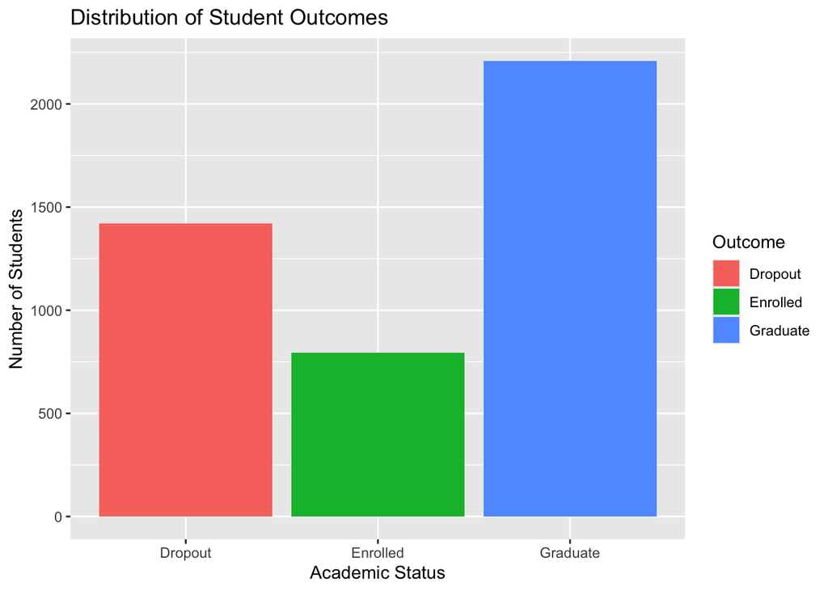

```r
#Response Variable Summary
ggplot(students, mapping = aes(x = target, fill = target)) +
  geom_bar() +
  labs(
    title = "Distribution of Student Outcomes",
    x = "Academic Status",
    y = "Number of Students" ,
    fill = "Outcome"
  )
```

The distribution shows that there is more students who have graduated than any other category. But it also should be pointed out that dropout is the second highest count of the three outcomes.

```r
#Numerical Variable Summary
students |>
  summarize(Min = min(admission_grade),
            Max = max(admission_grade),
            Median = median(admission_grade),
            SD = sd(admission_grade),
            IQR = IQR(admission_grade)
            )
```

```
##   Min Max Median      SD   IQR
## 1 1.9 3.8  2.522 0.28964 0.338
```

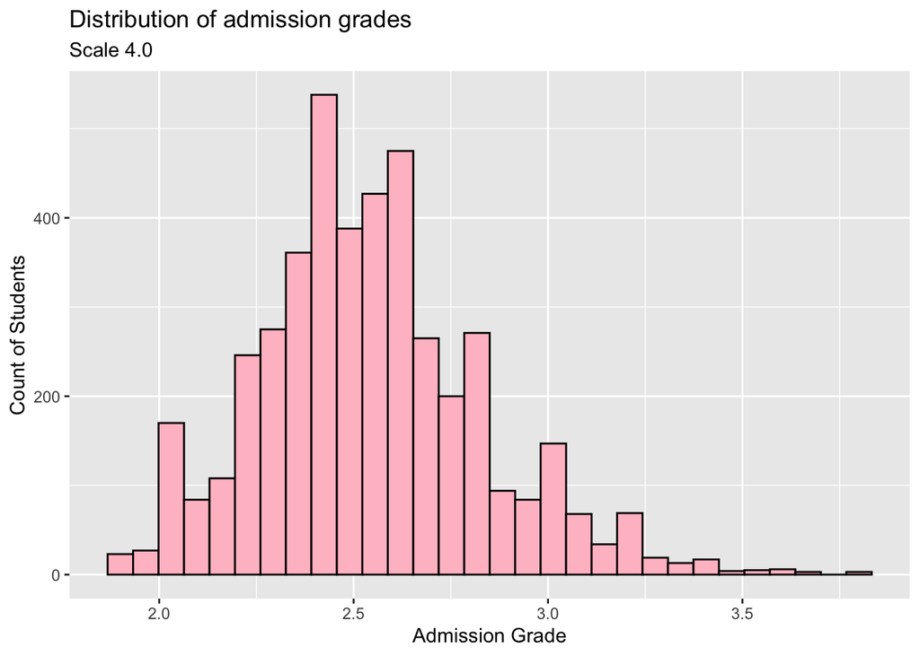

```r
ggplot(students, mapping = aes(x = admission_grade)) +
  geom_histogram(fill = "pink" , color = "black") +
  labs(
    title = "Distribution of admission grades",
    subtitle = "Scale 4.0",
    x = "Admission Grade" ,
    y = "Count of Students"
  )
```

The distribution for admission grades, shows a slight right skew with a unimodal shape, very few students received a GPA close to a 4.0 with the highest being a 3.8. While most students tend to land in the 2.5 range for GPA, the IQR was 0.338 with a SD of 0.289.

```r
#Numerical Variable Summary
students |>
  summarize(Min = min(age_at_enrollment),
            Max = max(age_at_enrollment),
            Median = median(age_at_enrollment),
            SD = sd(age_at_enrollment),
            IQR = IQR(age_at_enrollment)
            )
```

```
##   Min Max Median       SD IQR
## 1  17  70     20 7.587816   6
```

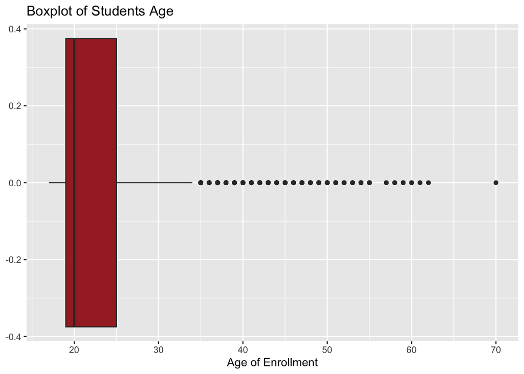

```r
ggplot(students, aes(x = age_at_enrollment)) +
  geom_boxplot(fill = "brown") +
  labs(
    title = "Boxplot of Students Age",
    x = "Age of Enrollment"
  )
```

This distribution is shows that most students tend to be around age 20, with a right skew indicating that there are older students enrolloing in higher education skewing the mean value.

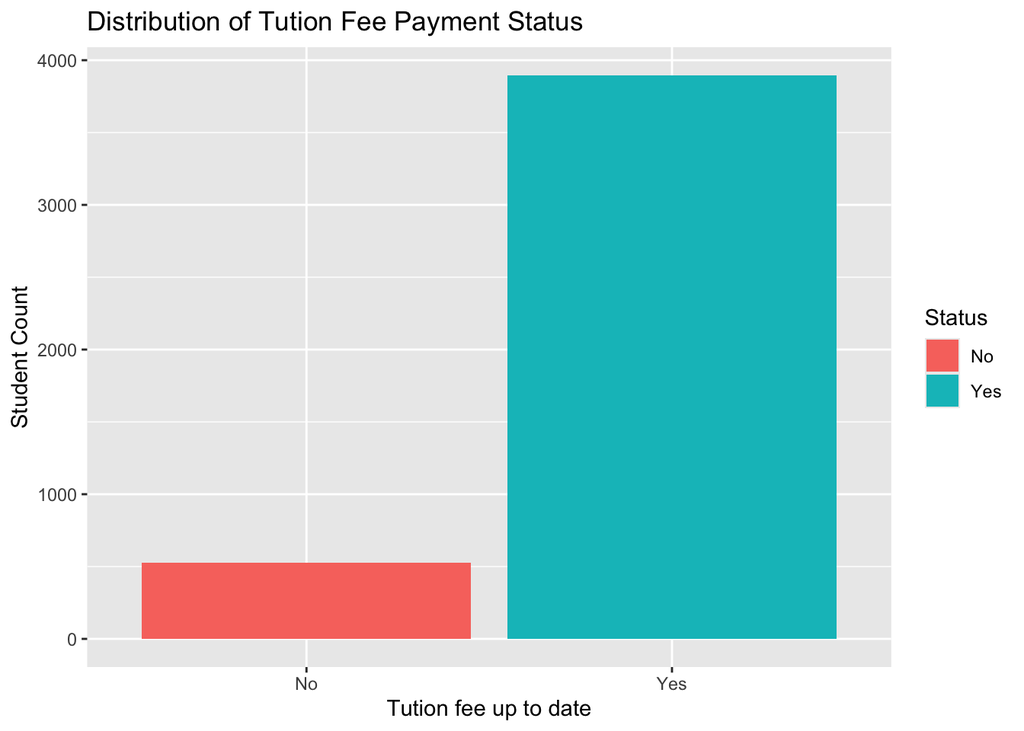

```r
#Categorical Predictor
ggplot(students, aes(x = tuition_fees_up_to_date, fill = tuition_fees_up_to_date)) +
  geom_bar()+
  labs(
    title = "Distribution of Tution Fee Payment Status",
    x = "Tution fee up to date",
    y = "Student Count",
    fill = "Status"
  )
```

The distribution indicates that there are a significant amount of students that have paid there tuition fee on time. Which can help us later determine if there is a correlation between the amount of students being able to pay for tuition on time has any relation with remaining in higher education. Since there is a higher amount of students who have graduated, this may be something to further investigate.

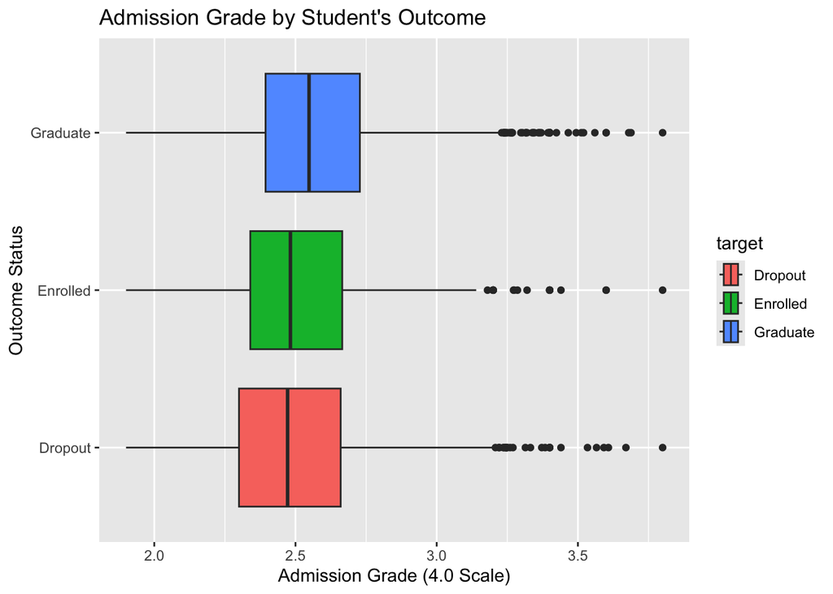

```r
#Target vs. admission grade
ggplot(students, aes(y = target, x = admission_grade, fill = target)) +
  geom_boxplot() +
  labs(
    title = "Admission Grade by Student's Outcome",
    y = "Outcome Status",
    x = "Admission Grade (4.0 Scale)"
  )
```

When examining the box plots we can see that all of the outcome have a skew towards the right indicating that the there are a few outlier students with higher GPA’s skewing the admissions grade. An interesting note we can examine is that the GPA for students who dropped out compared to students who either stayed enrolled or gradated does not have a significant GPA difference. This could indicate that there many be another variable affecting the enrollment of students instead simply GPA. Although it should be noted that the dropout category does have a higher distribution of low GPA’s.

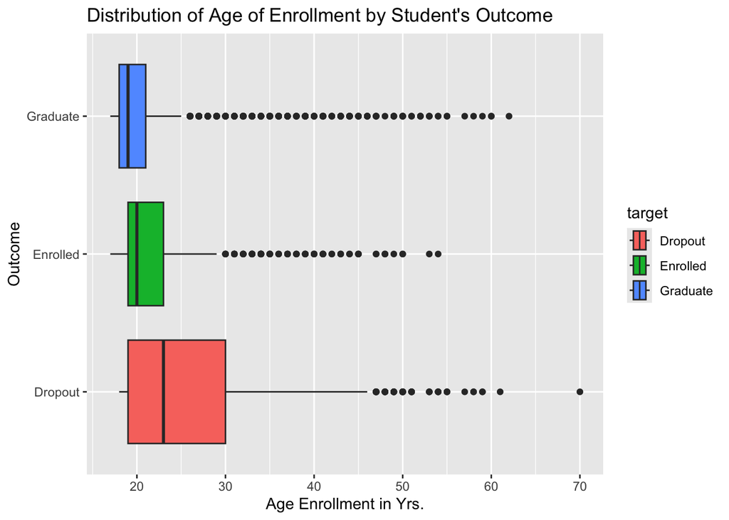

```r
ggplot(students, aes(y = target, x = age_at_enrollment, fill = target)) +
  geom_boxplot() +
  labs(
    title = "Distribution of Age of Enrollment by Student's Outcome",
    y = "Outcome",
    x = "Age Enrollment in Yrs."
  )
```

Age of enrollment was another demographic that needed to be examined to see any if there was any correlation between age and outcome. When examining the box plots we can see that those who graduated and stayed enrolled tended to be younger in age than those who dropout. Although we can also see that the 25th and 75th percentiles for the graduated and enrolled are significantly smaller than the dropouts. The max and min of the graduated and enrolled have a very short margin compared to dropouts with a median very close to the 25th percentile.

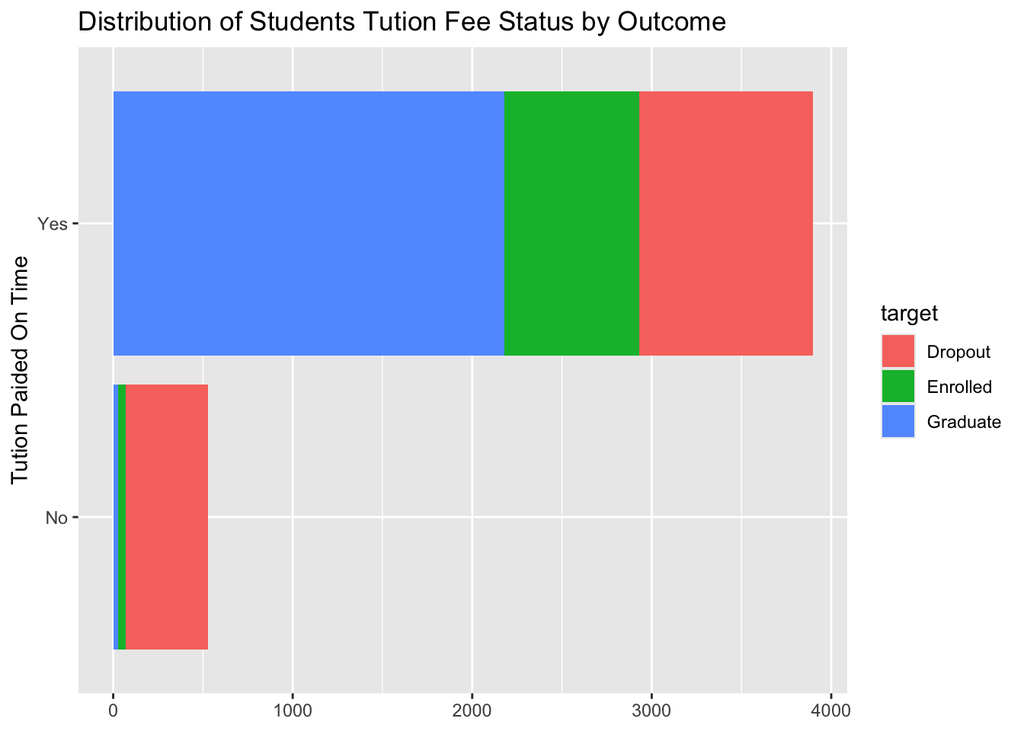

```r
ggplot(students, aes(y = tuition_fees_up_to_date, fill = target)) +
  geom_bar() +
  labs(
   title = "Distribution of Students Tution Fee Status by Outcome",
   y = "Tution Paided On Time",
   x = NULL
  )
```

We can see from the bar chat the distribution of students who have graduated and stayed enrolled in relation to paying student tuition on time. From this bar chat students who are able to pay for tution on time have a significantly higher distribution of staying enrolled and graduating compared to students who are not paying their tuition on time. This helps indicate that there may be a financial element that affects students ability to stay enrolled and or graduate from higher education.